# Cleaning_Tables

#### Traitement df1 Customers

|  | customer_id | customer_unique_id | customer_zip_code_prefix | customer_city | customer_state |
| --- | --- | --- | --- | --- | --- |
| 0 | 06b8999e2fba1a1fbc88172c00ba8bc7 | 861eff4711a542e4b93843c6dd7febb0 | 14409 | franca | SP |
| 1 | 18955e83d337fd6b2def6b18a428ac77 | 290c77bc529b7ac935b93aa66c333dc3 | 9790 | sao bernardo do campo | SP |

```
<class 'pandas.core.frame.DataFrame'>
RangeIndex: 99441 entries, 0 to 99440
Data columns (total 5 columns):
 #   Column                    Non-Null Count  Dtype
---  ------                    --------------  -----
 0   customer_id               99441 non-null  object
 1   customer_unique_id        99441 non-null  object
 2   customer_zip_code_prefix  99441 non-null  int64
 3   customer_city             99441 non-null  object
 4   customer_state            99441 non-null  object
dtypes: int64(1), object(4)
memory usage: 3.8+ MB
```

```
((99441, 5), (99441, 5))
```

- Il n'y a pas de doublons parfait.

##### Pas de valeur manquantes dans la tables

##### Customer_id : La clé du client dans la table commande

##### Customer_unique_id : l'identifiant unique du client.

```
<class 'pandas.core.frame.DataFrame'>
RangeIndex: 99441 entries, 0 to 99440
Data columns (total 5 columns):
 #   Column                    Non-Null Count  Dtype
---  ------                    --------------  -----
 0   customer_id               99441 non-null  object
 1   customer_unique_id        99441 non-null  object
 2   customer_zip_code_prefix  99441 non-null  int64
 3   customer_city             99441 non-null  object
 4   customer_state            99441 non-null  object
dtypes: int64(1), object(4)
memory usage: 3.8+ MB
```

```
(0, 5)
```

```
(6342, 5)
```

Pas de doublons sur l'identifiant du client dans la table des commandes  
Il y a 6342 valeurs en doubles sur les identifiants unique de clients

#### Analyse exploratoire

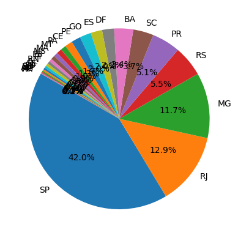

#### Les etats où la clientele est la plus représentée sont : Sao Paulo (SP) (42.0%), RJ (12.9%) & MG (11.7%)

### Traitement df2 orders_items_datasets

|  | order_id | order_item_id | product_id | seller_id | shipping_limit_date | price | freight_value |
| --- | --- | --- | --- | --- | --- | --- | --- |
| 0 | 00010242fe8c5a6d1ba2dd792cb16214 | 1 | 4244733e06e7ecb4970a6e2683c13e61 | 48436dade18ac8b2bce089ec2a041202 | 2017-09-19 09:45:35 | 58.9 | 13.29 |
| 1 | 00018f77f2f0320c557190d7a144bdd3 | 1 | e5f2d52b802189ee658865ca93d83a8f | dd7ddc04e1b6c2c614352b383efe2d36 | 2017-05-03 11:05:13 | 239.9 | 19.93 |

```
((112650, 7), (112650, 7))
```

- Il n'y a pas de doublons parfait

```
order_id               0
order_item_id          0
product_id             0
seller_id              0
shipping_limit_date    0
price                  0
freight_value          0
dtype: int64
```

- 23787 duplicates values by order_id Garder les doublons

### Cette table regroupes les articles

- order_id : Identifiant unique de la commande
- order_item_id : Identifiant séquentiel des items d'une même commande (lignes de commande)
- product_id : Identifiant unique du produit
- seller_id : Identifiant unique du vendeur
- price : Prix de la ligne de commande
- freight_value : Coût de fret de la ligne (Si plusieurs lignes, le coût de fret est réparti entre toutes les lignes)

### Traitement df3 orders_payment_datasets

|  | order_id | payment_sequential | payment_type | payment_installments | payment_value |
| --- | --- | --- | --- | --- | --- |
| 0 | b81ef226f3fe1789b1e8b2acac839d17 | 1 | credit_card | 8 | 99.33 |
| 1 | a9810da82917af2d9aefd1278f1dcfa0 | 1 | credit_card | 1 | 24.39 |

|  | order_id | payment_sequential | payment_type | payment_installments | payment_value |
| --- | --- | --- | --- | --- | --- |
| 25 | 5cfd514482e22bc992e7693f0e3e8df7 | 2 | voucher | 1 | 45.17 |
| 35 | b2bb080b6bc860118a246fd9b6fad6da | 1 | credit_card | 1 | 173.84 |
| 75 | 3689194c14ad4e2e7361ebd1df0e77b0 | 2 | voucher | 1 | 57.53 |
| 84 | 723e462ce1ee50e024887c0b403130f3 | 1 | credit_card | 1 | 13.80 |
| 102 | 21b8b46679ea6482cbf911d960490048 | 2 | voucher | 1 | 43.12 |

|  | order_id | payment_sequential | payment_type | payment_installments | payment_value |
| --- | --- | --- | --- | --- | --- |
| count | 103886 | 103886.000000 | 103886 | 103886.000000 | 103886.000000 |
| unique | 99440 | NaN | 5 | NaN | NaN |
| top | fa65dad1b0e818e3ccc5cb0e39231352 | NaN | credit_card | NaN | NaN |
| freq | 29 | NaN | 76795 | NaN | NaN |
| mean | NaN | 1.092679 | NaN | 2.853349 | 154.100380 |
| std | NaN | 0.706584 | NaN | 2.687051 | 217.494064 |
| min | NaN | 1.000000 | NaN | 0.000000 | 0.000000 |
| 25% | NaN | 1.000000 | NaN | 1.000000 | 56.790000 |
| 50% | NaN | 1.000000 | NaN | 1.000000 | 100.000000 |
| 75% | NaN | 1.000000 | NaN | 4.000000 | 171.837500 |
| max | NaN | 29.000000 | NaN | 24.000000 | 13664.080000 |

La plupart des paiements des produits se fait via **credi_card**

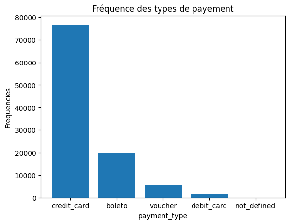

### Traitement df4 orders_reviews_datasets

|  | review_id | order_id | review_score | review_comment_title | review_comment_message | review_creation_date | review_answer_timestamp |
| --- | --- | --- | --- | --- | --- | --- | --- |
| 0 | 7bc2406110b926393aa56f80a40eba40 | 73fc7af87114b39712e6da79b0a377eb | 4 | NaN | NaN | 2018-01-18 00:00:00 | 2018-01-18 21:46:59 |
| 1 | 80e641a11e56f04c1ad469d5645fdfde | a548910a1c6147796b98fdf73dbeba33 | 5 | NaN | NaN | 2018-03-10 00:00:00 | 2018-03-11 03:05:13 |

|  | review_id | order_id | review_score | review_comment_title | review_comment_message | review_creation_date | review_answer_timestamp |
| --- | --- | --- | --- | --- | --- | --- | --- |
| 0 | 7bc2406110b926393aa56f80a40eba40 | 73fc7af87114b39712e6da79b0a377eb | 4 | NaN | NaN | 2018-01-18 00:00:00 | 2018-01-18 21:46:59 |
| 1 | 80e641a11e56f04c1ad469d5645fdfde | a548910a1c6147796b98fdf73dbeba33 | 5 | NaN | NaN | 2018-03-10 00:00:00 | 2018-03-11 03:05:13 |

### Traitement df5 orders

|  | order_id | customer_id | order_status | order_purchase_timestamp | order_approved_at | order_delivered_carrier_date | order_delivered_customer_date | order_estimated_delivery_date |
| --- | --- | --- | --- | --- | --- | --- | --- | --- |
| 0 | e481f51cbdc54678b7cc49136f2d6af7 | 9ef432eb6251297304e76186b10a928d | delivered | 2017-10-02 10:56:33 | 2017-10-02 11:07:15 | 2017-10-04 19:55:00 | 2017-10-10 21:25:13 | 2017-10-18 00:00:00 |
| 1 | 53cdb2fc8bc7dce0b6741e2150273451 | b0830fb4747a6c6d20dea0b8c802d7ef | delivered | 2018-07-24 20:41:37 | 2018-07-26 03:24:27 | 2018-07-26 14:31:00 | 2018-08-07 15:27:45 | 2018-08-13 00:00:00 |

```
((99441, 8), (99441, 8), (0, 8))
```

```
order_id                            0
customer_id                         0
order_status                        0
order_purchase_timestamp            0
order_approved_at                 160
order_delivered_carrier_date     1783
order_delivered_customer_date    2965
order_estimated_delivery_date       0
dtype: int64
```

```
<class 'pandas.core.frame.DataFrame'>
RangeIndex: 99441 entries, 0 to 99440
Data columns (total 8 columns):
 #   Column                         Non-Null Count  Dtype
---  ------                         --------------  -----
 0   order_id                       99441 non-null  object
 1   customer_id                    99441 non-null  object
 2   order_status                   99441 non-null  object
 3   order_purchase_timestamp       99441 non-null  object
 4   order_approved_at              99281 non-null  object
 5   order_delivered_carrier_date   97658 non-null  object
 6   order_delivered_customer_date  96476 non-null  object
 7   order_estimated_delivery_date  99441 non-null  object
dtypes: object(8)
memory usage: 6.1+ MB
```

```
order_status
delivered      96478
shipped         1107
canceled         625
unavailable      609
invoiced         314
processing       301
created            5
approved           2
Name: count, dtype: int64
```

### Focus sur les commandes délivrées

```
order_id                          0
customer_id                       0
order_status                      0
order_purchase_timestamp          0
order_approved_at                14
order_delivered_carrier_date      2
order_delivered_customer_date     8
order_estimated_delivery_date     0
dtype: int64
```

#### * On retrouve quelques nans sur les variables date de payement de la commande, la date de notification de la commande à la logistic et la date de réception de la commande par le client.

```
Timedelta('0 days 10:16:36.361243572')
```

```
Timedelta('2 days 19:10:52.038019818')
```

```
order_id                         0
customer_id                      0
order_status                     0
order_purchase_timestamp         0
order_approved_at                0
order_delivered_carrier_date     0
order_delivered_customer_date    8
order_estimated_delivery_date    0
dtype: int64
```

```
Timedelta('9 days 07:56:13.591106043')
```

```
order_id                         0
customer_id                      0
order_status                     0
order_purchase_timestamp         0
order_approved_at                0
order_delivered_carrier_date     0
order_delivered_customer_date    8
order_estimated_delivery_date    0
dtype: int64
```

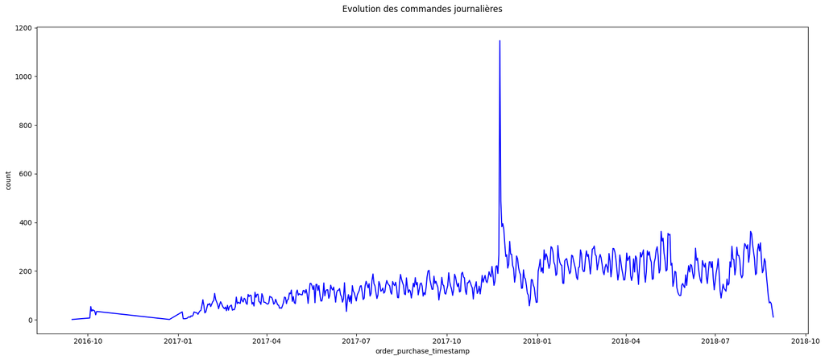

### Traitement df6 olist_products_datasets

|  | product_id | product_category_name | product_name_lenght | product_description_lenght | product_photos_qty | product_weight_g | product_length_cm | product_height_cm | product_width_cm |
| --- | --- | --- | --- | --- | --- | --- | --- | --- | --- |
| 0 | 1e9e8ef04dbcff4541ed26657ea517e5 | perfumaria | 40.0 | 287.0 | 1.0 | 225.0 | 16.0 | 10.0 | 14.0 |
| 1 | 3aa071139cb16b67ca9e5dea641aaa2f | artes | 44.0 | 276.0 | 1.0 | 1000.0 | 30.0 | 18.0 | 20.0 |

```
73
```

#### IL y a 73 categorie de produits différents

```
(product_id                      0
 product_category_name         610
 product_name_lenght           610
 product_description_lenght    610
 product_photos_qty            610
 product_weight_g                2
 product_length_cm               2
 product_height_cm               2
 product_width_cm                2
 dtype: int64,
 (32951, 9))
```

|  | product_id | product_category_name | product_name_lenght | product_description_lenght | product_photos_qty | product_weight_g | product_length_cm | product_height_cm | product_width_cm |
| --- | --- | --- | --- | --- | --- | --- | --- | --- | --- |
| 8578 | 09ff539a621711667c43eba6a3bd8466 | bebes | 60.0 | 865.0 | 3.0 | NaN | NaN | NaN | NaN |
| 18851 | 5eb564652db742ff8f28759cd8d2652a | NaN | NaN | NaN | NaN | NaN | NaN | NaN | NaN |

### Nous supprimons la ligne 18851 car toutes les obs sont quasiment vides

```
['product_name_lenght',
 'product_description_lenght',
 'product_photos_qty',
 'product_weight_g',
 'product_length_cm',
 'product_height_cm',
 'product_width_cm']
```

```
product_id                    0
product_category_name         0
product_name_lenght           0
product_description_lenght    0
product_photos_qty            0
product_weight_g              0
product_length_cm             0
product_height_cm             0
product_width_cm              0
dtype: int64
```

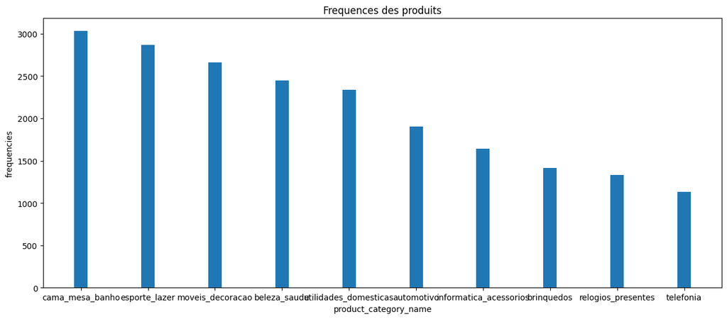

#### Les produits les plus vendus sont : cama_mesa_banho, esporte_lazer et movies_decoracao

|  | product_id | product_category_name | product_name_lenght | product_description_lenght | product_photos_qty | product_weight_g | product_length_cm | product_height_cm | product_width_cm |
| --- | --- | --- | --- | --- | --- | --- | --- | --- | --- |
| count | 32950 | 32950 | 32950.000000 | 32950.000000 | 32950.000000 | 32950.000000 | 32950.000000 | 32950.000000 | 32950.000000 |
| unique | 32950 | 74 | NaN | NaN | NaN | NaN | NaN | NaN | NaN |
| top | 1e9e8ef04dbcff4541ed26657ea517e5 | cama_mesa_banho | NaN | NaN | NaN | NaN | NaN | NaN | NaN |
| freq | 1 | 3029 | NaN | NaN | NaN | NaN | NaN | NaN | NaN |
| mean | NaN | NaN | 48.468134 | 771.486131 | 2.185493 | 2276.472473 | 30.815053 | 16.937633 | 23.196722 |
| std | NaN | NaN | 10.150816 | 629.218401 | 1.720829 | 4281.973751 | 16.914202 | 13.637348 | 12.078864 |
| min | NaN | NaN | 5.000000 | 4.000000 | 1.000000 | 0.000000 | 7.000000 | 2.000000 | 6.000000 |
| 25% | NaN | NaN | 42.000000 | 344.000000 | 1.000000 | 300.000000 | 18.000000 | 8.000000 | 15.000000 |
| 50% | NaN | NaN | 51.000000 | 604.000000 | 1.000000 | 700.000000 | 25.000000 | 13.000000 | 20.000000 |
| 75% | NaN | NaN | 57.000000 | 961.000000 | 3.000000 | 1900.000000 | 38.000000 | 21.000000 | 30.000000 |
| max | NaN | NaN | 76.000000 | 3992.000000 | 20.000000 | 40425.000000 | 105.000000 | 105.000000 | 118.000000 |

### Traitement df6 products_categories

|  | product_category_name | product_category_name_english |
| --- | --- | --- |
| 0 | beleza_saude | health_beauty |
| 1 | informatica_acessorios | computers_accessories |
| 2 | automotivo | auto |
| 3 | cama_mesa_banho | bed_bath_table |
| 4 | moveis_decoracao | furniture_decor |

### Merge datasets

|  | order_id | customer_id | order_status | order_purchase_timestamp | order_approved_at | order_delivered_carrier_date | order_delivered_customer_date | order_estimated_delivery_date |
| --- | --- | --- | --- | --- | --- | --- | --- | --- |
| 0 | e481f51cbdc54678b7cc49136f2d6af7 | 9ef432eb6251297304e76186b10a928d | delivered | 2017-10-02 10:56:33 | 2017-10-02 11:07:15 | 2017-10-04 19:55:00 | 2017-10-10 21:25:13 | 2017-10-18 00:00:00 |

```
((96478, 8), (112650, 7))
```

#### Grouper par customer_unique_id en creant les features d'aggrégation

```
'bed_bath_table'
```

```
Index(['order_id', 'customer_id', 'order_status', 'order_purchase_timestamp',
       'order_approved_at', 'order_delivered_carrier_date',
       'order_delivered_customer_date', 'order_estimated_delivery_date',
       'order_item_id', 'product_id', 'seller_id', 'shipping_limit_date',
       'price', 'freight_value', 'review_id', 'review_score',
       'review_comment_title', 'review_comment_message',
       'review_creation_date', 'review_answer_timestamp', 'payment_sequential',
       'payment_type', 'payment_installments', 'payment_value',
       'customer_unique_id', 'customer_zip_code_prefix', 'customer_city',
       'customer_state', 'product_category_name', 'product_name_lenght',
       'product_description_lenght', 'product_photos_qty', 'product_weight_g',
       'product_length_cm', 'product_height_cm', 'product_width_cm',
       'product_category_name_english', 'duration_deliv'],
      dtype='object')
```

#### Features agrégation

|  | customer_unique_id | Monetary | frequency | review_score_mean | payment_type_mode | product_w_mean | product_mode | recently |
| --- | --- | --- | --- | --- | --- | --- | --- | --- |
| 0 | 0000366f3b9a7992bf8c76cfdf3221e2 | 141.90 | 1 | 5.0 | credit_card | 1500.0 | bed_bath_table | 111 days 03:59:08 |
| 1 | 0000b849f77a49e4a4ce2b2a4ca5be3f | 27.19 | 1 | 4.0 | credit_card | 375.0 | health_beauty | 113 days 20:44:42 |
| 2 | 0000f46a3911fa3c0805444483337064 | 86.22 | 1 | 3.0 | credit_card | 1500.0 | stationery | 536 days 18:05:23 |
| 3 | 0000f6ccb0745a6a4b88665a16c9f078 | 43.62 | 1 | 4.0 | credit_card | 150.0 | telephony | 320 days 18:21:09 |
| 4 | 0004aac84e0df4da2b147fca70cf8255 | 196.89 | 1 | 5.0 | credit_card | 6050.0 | telephony | 287 days 19:03:34 |

#### Nous avons crée 7 variables agrégées caractérisant les clients notamment : le R-F-M, la moyen des scores des reviews, le type de payement le plus frequent, le poids moyen des produits, le produit le plus acheté.

### ANALYSE DESCRIPTIVE DE LA TABLE AGREGEE

|  | customer_unique_id | Monetary | frequency | review_score_mean | payment_type_mode | product_w_mean | product_mode | recently |
| --- | --- | --- | --- | --- | --- | --- | --- | --- |
| count | 93346 | 93346.000000 | 93346.000000 | 92714.000000 | 93346 | 93346.000000 | 93346 | 93346 |
| unique | 93346 | NaN | NaN | NaN | 1940 | NaN | 2914 | NaN |
| top | 0000366f3b9a7992bf8c76cfdf3221e2 | NaN | NaN | NaN | credit_card | NaN | bed_bath_table | NaN |
| freq | 1 | NaN | NaN | NaN | 69735 | NaN | 8584 | NaN |
| mean | NaN | 211.847823 | 1.033392 | 4.153972 | NaN | 2102.052525 | NaN | 237 days 00:21:40.921132132 |
| std | NaN | 642.202727 | 0.209039 | 1.280403 | NaN | 3729.862009 | NaN | 152 days 14:06:55.364170496 |
| min | NaN | 0.000000 | 1.000000 | 1.000000 | NaN | 0.000000 | NaN | 0 days 00:00:00 |
| 25% | NaN | 63.772500 | 1.000000 | 4.000000 | NaN | 300.000000 | NaN | 113 days 10:36:46.750000 |
| 50% | NaN | 112.965000 | 1.000000 | 5.000000 | NaN | 700.000000 | NaN | 218 days 01:57:04 |
| 75% | NaN | 201.747500 | 1.000000 | 5.000000 | NaN | 1825.000000 | NaN | 345 days 01:31:22.250000 |
| max | NaN | 109312.640000 | 15.000000 | 5.000000 | NaN | 40425.000000 | NaN | 713 days 02:53:48 |

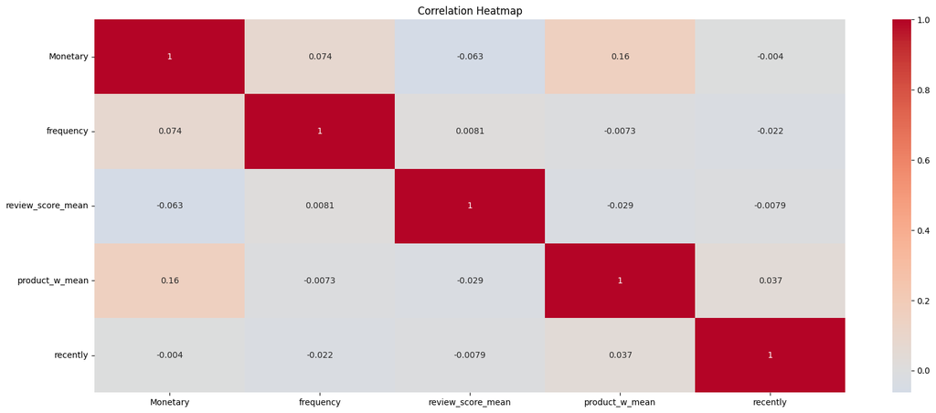

##### IL n'y a pas de fortes corrélations entre les variables agrégées

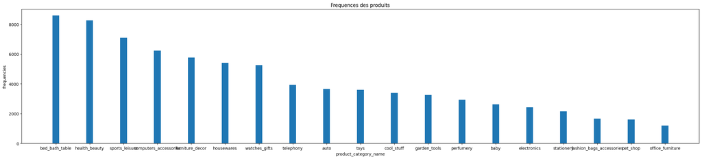

```
array(['credit_card', 'boleto', 'debit_card', 'voucher', nan],
      dtype=object)
```

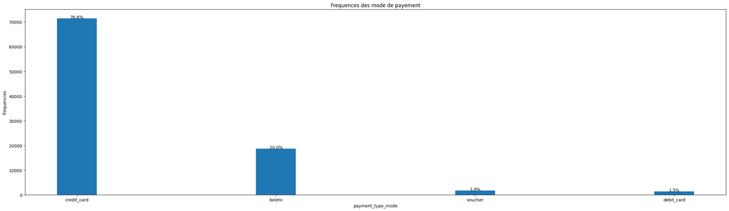

```
['Monetary', 'frequency', 'review_score_mean', 'product_w_mean', 'recently']
```

### Analyse uni-bivariées des vars continues

#### *** Diagramme en violon

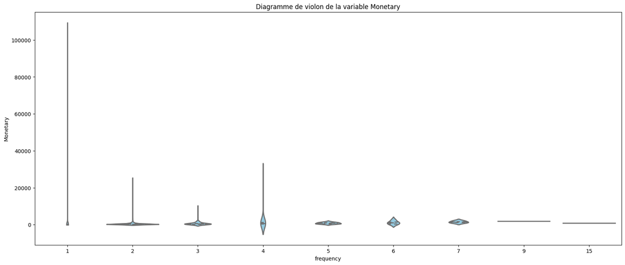

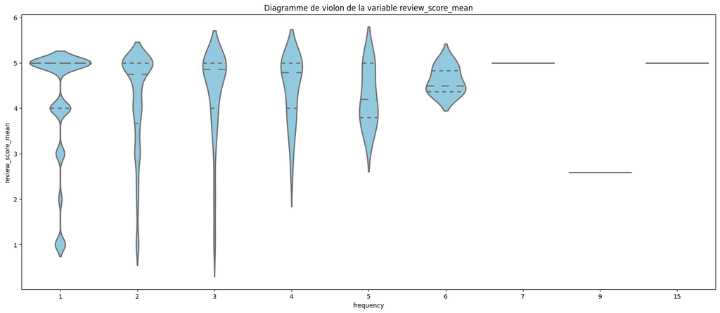

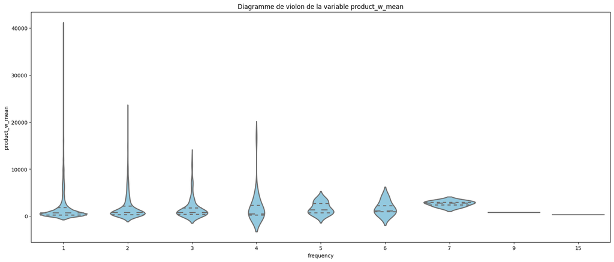

[output not shown]